# Deep Dive into Amazon Co-Purchases Network Behavior

Ammar Bagharib, Chen Yang, Ng Qing Yu Randy

NUS AY2023/24 Semester 1

# 1 Introduction

Established in 1995 as a pioneering online bookstore, Amazon has been a cherished destination for book enthusiasts for several decades. While the company has evolved and expanded into a diverse range of industries, it has consistently maintained its status as a go-to hub for book shoppers.

In the scope of this project, our objective is to delve into the evolving co-purchase patterns of books over time, understand it’s characteristics and underlying patterns. With this information, we’re looking to identify key products which drive purchasing behaviour among consumers, devise marketing strategies, as well as to assess the efficacy of incorporating network analytics into the development of product recommendation engines.

In doing so, we anticipate that our efforts will yield a mutually beneficial outcome. By facilitating book discoveries and guiding readers to titles they might not have encountered otherwise, we aim to stimulate sales on the platform, benefiting both Amazon and its thriving community of book lovers.

# 2 About the Dataset

In our project, we used the amazon co-purchase dataset from Stanford University’s SNAP library. The dataset was compiled through an extensive crawl of the Amazon website in the summer of 2006, capturing a vast array of product metadata and review details for 548,552 diverse items, spanning categories such as Books, music CDs, DVDs, and VHS video tapes. It encompasses comprehensive information for each product, including titles, sales ranks, and genre or category information. In our analysis, we restricted the product scope to books only.

Specifically, we delved into the structure of the network as of March 2006 and developed our model around it. In our network, each node represents a book and each undirected edge represent the co-purchase relationship between two books. To supplement our analysis, we extracted the product ID, name, genre, product rank and review count information for all books to be included as node attributes.

## 2.1 Network Sampling

### 2.1.1 Methodology:

To enable us to compute some of the key network metrics efficiently, we opted to sample 100,000 nodes from the network. This approach offers a practical means of analysis while retaining a substantial portion of the network’s complexity. Steps taken in our sampling process are as follows:

**Step 1:** load graph, and filter for nodes with degree > 1, and set this as the graph we’ll be working with.

**Step 1:** filter for books which have reviews > 1 per 1.25 months

**Step 2:** filter for books which have valid genres I.e., non-empty strings

**Step 3:** filter for links in which both ‘from’ and ‘to’ books follow the conditions outlined in the steps 1 and 2

**Step 4:** extract the indices of nodes from step 3, lets define this as nodes_1, and get the count of nodes. Let’s define the counts of these nodes as `x`

**Step 5:** get count of remaining nodes needed to sample: y = (100,000-x)

**Step 6:** sample y indices of nodes from setdiff(1:length(V(g)), nodes). Let’s label these nodes as nodes_2

**Step 7:** combine nodes_1 and nodes_2 indices and obtain subgraph from g using these indices.

**Step 8:** generate network metrics for subgraph, after which we filter only for the nodes present in nodes_1, and save it in a data frame.

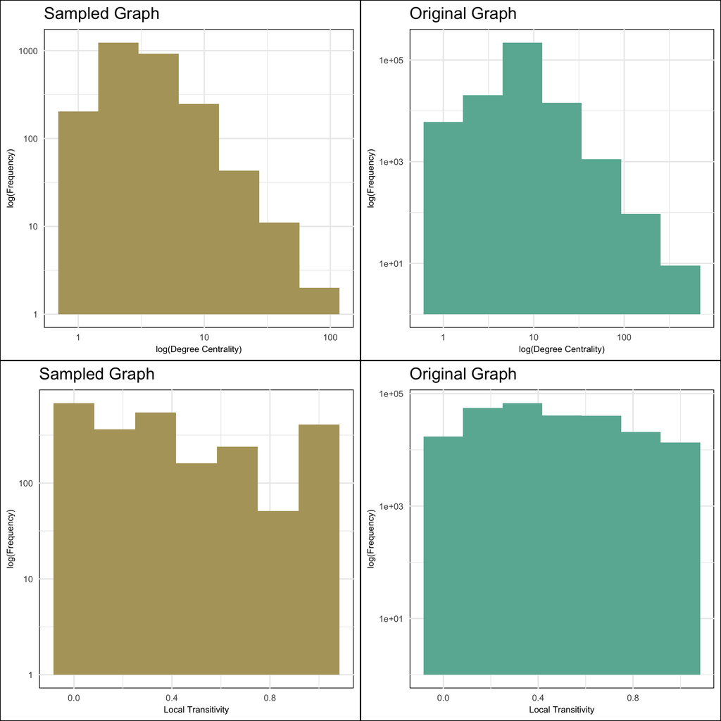

By selecting a significant subset, we aim to strike a balance between computational efficiency and preserving the network’s fundamental properties. This method allows us to derive meaningful insights and draw reliable conclusions about the overall network dynamics without the computational burden of analyzing the entire network.

# 3 Network Structure

We performed some basic analysis to draw some insights on the purchasing pattern of books on Amazon.

## 3.1 Degree Distribution

As we can see in fig. 3.1.1, the degree distribution of our network exhibits a power-law distribution, a characteristic often seen in naturally occurring networks.

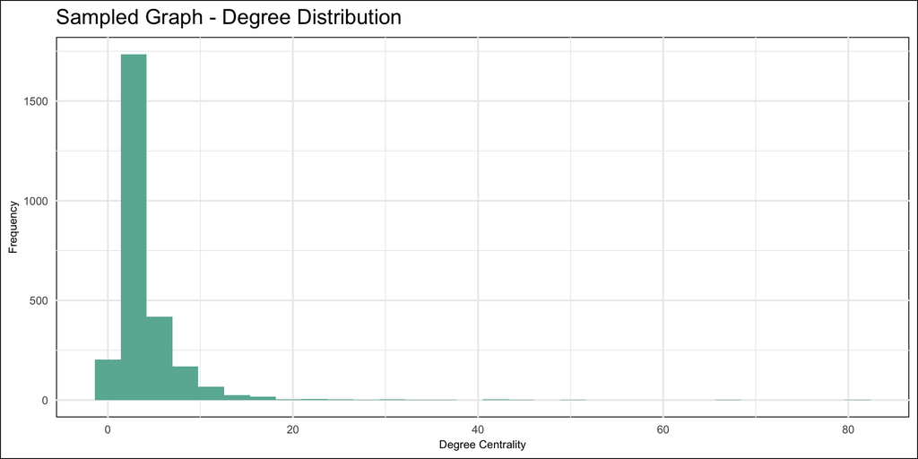

Figure 3.1: Degree Centrality Distribution

Majority of books in our network have low degree centrality, with approximately 3 or fewer connections. On the far right of the distribution, we observe a small group of books with approximately 70 first-degree connections, indicating a significant influence on the purchase of other books. This suggests that most books within the network neither strongly influence the purchase of other books nor are significantly influenced by other books.

## 3.2 Density and Transitivity

Table 3.1: Density and Global Transitivity

| Metric | Value |
| --- | --- |
| Global Transitivity | 0.2327958 |
| Density | 0.0000277 |

Taken together, this means that books within the network are not frequently co-purchased together, and individual products seem to have limited influence on the purchasing behaviour of others. This disconnectedness further highlights the challenge in seeking out cross-selling opportunities, as there are few evident connections or influences between various types of books.

## 3.3 PageRank

We observed a noteworthy similarity between the distribution of PageRank and degree centrality in our network as seen in Figure 3.2. Both distributions exhibit a power-law pattern, wherein a small number of books boast significantly higher PageRank scores than the rest.

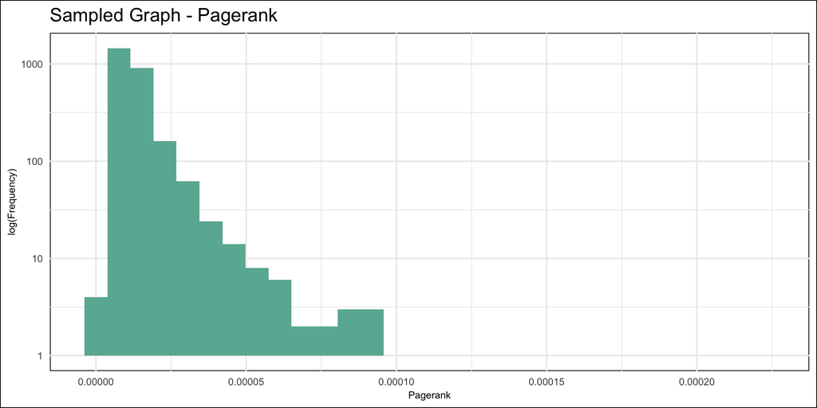

Figure 3.2: Pagerank Distribution

Table 3.2: Top 10 Books by Pagerank

| vertex_name | pagerank |
| --- | --- |
| 5765 | 0.0002256 |
| 37780 | 0.0001477 |
| 56817 | 0.0001233 |
| 2555 | 0.0001090 |
| 19526 | 0.0000958 |
| 2563 | 0.0000933 |
| 2423 | 0.0000921 |
| 976 | 0.0000881 |
| 3247 | 0.0000867 |
| 36122 | 0.0000832 |

| Genre | Count |
| --- | --- |
| Literature & Fiction | 34 |
| Science Fiction & Fantasy | 14 |
| Biographies & Memoirs | 12 |
| Contemporary | 12 |
| Nonfiction | 12 |
| Series | 11 |
| Fantasy | 10 |
| Mystery & Thrillers | 10 |
| Books on Tape | 9 |
| Children’s Books | 9 |
| Genre Fiction | 8 |

# 4 Network Analytics’ Impact on Amazon’s Recommendation Engine

Considering Amazon’s position as a leading tech company renowned for employing diverse cutting-edge techniques and algorithms within its recommendation engine, one noteworthy approach utilized is the integration of network analytics in its item-to-item collaborative filtering system (Muralidharan, 2023). To further narrow down our scope of analysis, we decided to only focus on books which have at least 1 review per month and valid genre information. We hypothesize that the incorporation of network analytics is a valuable method capable of enhancing predictive accuracy. To test this hypothesis, we have developed two models for the purpose of link prediction.

The first model type serves as a baseline, incorporating solely item-specific features including genre, number of reviews, and item ranking. The second model type, an alternative approach, uses only network metrics such as degree centrality, pagerank centrality, community etc., just to name a few. Our aim is to assess and compare the predictive performance of these models to determine the potential impact and effectiveness of incorporating network-based metrics within the recommendation system.

Our model of choice is a logistic regression. We believe that it is the most appropriate model because our problem at hand is binary in nature, and logistic regression outputs predicted probabilities that can be rounded to 0 or 1 based on some criteria. Additionally, logistic regression is not a ‘black-box’ model where we cannot see the training process, but rather we can fully understand the estimation process as it typically uses maximum likelihood estimation (MLE). Lastly, the coefficients of the logistic regression are also easily interpretable, where we can infer and gauge the contribution of each independent variable to the dependent variable.

## 4.1 Methodology

First, we exhaustively created all conceivable pairings among the books within our network. After this stage, we specifically isolated connected pairs to serve as our positive data points, while the unconnected pairs were designated as our negative data points. Each data point captured information such as the number of shared genres between the paired books, along with individual book attributes including sales rank and review counts. For our alternative model, we expanded the feature set by integrating additional node attributes derived from the network. These supplementary attributes encompassed the main network related measures:

```
1. Degree
2. Betweenness
3. Closeness
4. Local transitivity
5. PageRank
6. Eigenvector centrality
7. Louvrain Community membership
```

These serve as the training dataset for our two models.

### 4.1.1 Downsampling of Negative Data Points

However, the disparity in numbers between the negative and positive data points, mainly owing to the sparse nature of our network, posed a significant challenge. To address this imbalance, we adopted a strategic approach, opting to randomly down-sample the excessive negative data points, thereby achieving a balanced representation of positive and negative instances. We opted for downsampling instead of upsampling based on 2 considerations, with the first being downsampling requiring much less computational resources. Secondly, upsampling methods such as Synthetic Minority Oversampling Technique (SMOTE), which generates new samples of the minority class based on an unsupervised machine learning method, is not appropriate. This is because the counts of positive class are too little, which would render the algorithm to not be able to learn properly, and thus, also disrupt the overall network structure. Therefore, we believe that downsampling is the appropriate choice. Subsequently, the datasets have an equal proportion of positive and negative classes.

Given the downsampling of our negative data points, the conventional use of metrics such as F1 score, precision, and recall became inappropriate, as the dataset no longer accurately represented the true distribution of positive and negative instances. Consequently, we directed our focus solely towards evaluating the predictive accuracy concerning the positive cases in our model, recognizing the need to adapt our evaluation approach in response to the modified dataset composition.

### 4.1.2 Handling of NA values

Handling of NA values are essential in ensuring that model training and model prediction can occur. In the training and the test datasets, with regards to networks metrics, namely local transitivity and closeness centralities had NA values. It is not unreasonable for there to be NA values because it means that it is an isolated node. As such, we decided that the most appropriate value to represent NA values with the value: –1. This is because transitivity is a numerical variable with values that are usually positive. Thus, to not confound with the numeric meaning of typical transitivity and closeness values, we believe that the number –1 will still be able capture the essence of the datapoints with ‘NA’ values.

### 4.1.3 Scaling of data

Scaling features before fitting a logistic regression model is crucial because it ensures that each feature contributes equally to the determination of the outcome. Logistic regression uses gradient descent as an optimization technique, which converges much faster when features are on similar scales. Without scaling, features with large values can disproportionately influence the model and result in an unstable training process, where the algorithm might oscillate and take a long time to find the global minimum, or potentially not converge at all. Thus, we used to use standard scaling for our dataset, which subtract the mean of the variable from each datapoint then divide it by its standard deviation. This ensures that each variable has a mean of 0 and a standard deviation of 1. There are alternative forms of scaling such as min-max scaling, but we believe that standard-scaling is sufficient for our case.

### 4.1.4 Objective of our Models

The primary objective is for our model to discern the inherent patterns between these features and our target variable, which determines whether two books are co-purchased. To construct our testing set, we did not utilise the traditional train-test-split approach. Instead, we gathered node pairs that formed new connections between March and June. In essence, these pairs represent books that established co-purchase relationships during this time frame. This was achieved by getting all node pairs which are connected in June and further filtering out pairs already linked in March. From these selected node pairs, we retrieved their respective features for our baseline and alternative models. With our testing datasets, we then applied our two models and compared their respective accuracy scores.

## 4.2 Findings

Table 4.1: Regression Results

| Model | Accuracy |
| --- | --- |
| baseline 0302 | 0.4491811 |
| network metrics 0302 | 0.4932563 |
| baseline + network metrics 0302 | 0.4879576 |

## 4.3 Recency of Data

We further hypothesize that incorporating more recent information or datasets could yield improvements in the model’s performance. To test this hypothesis, we opted to utilize network metrics from May for the node pairs in our training dataset. Consequently, we re-trained our model, anticipating that this adjustment would provide the algorithm with a more current and nuanced understanding of the network’s dynamics.

Table 4.2: Regression Results

| Model | Accuracy |
| --- | --- |
| baseline 0302 | 0.4491811 |
| network metrics 0302 | 0.4932563 |
| baseline + network metrics 0302 | 0.4879576 |
| network metrics 0505 | 0.6180154 |

# 5 Conclusion

In conclusion, our project has underscored the transformative potential of network analytics in reshaping marketing strategies. By leveraging tools like PageRank, marketers can effectively identify influential products affecting consumers’ copurchasing behaviour. This insight allows for the formulation of effective sales strategies, such as prominently featuring high PageRank products in strategic locations frequented by consumers.

Lastly, an additional key observation is the significance of incorporating recent network metrics. Our findings emphasize the dynamic nature of Amazon’s copurchase network, where constant changes occur. Recognizing this dynamism, we advocate for the importance of regularly updating the model with the most recent data. This practice ensures not only accurate link predictions but also the delivery of relevant personalized recommendations, aligning marketing strategies with the evolving landscape of consumer behaviour on Amazon’s platform.

# 6 Limitations and Considerations

While our study yielded promising results, we acknowledge several potential weaknesses that could be addressed in future iterations. One primary limitation is the absence of edge weights in our dataset. As a result, products with numerous co-purchases are considered equal to those with only a few, disregarding the differential influence levels these products might have on consumers’ purchasing patterns. Incorporating edge weight information would significantly enhance our ability to make informed decisions regarding product bundling and recommendations. Additionally, it would bolster the predictive power of our models, showcasing the tangible impact of including network metrics as features. However, obtaining such detailed data is restricted to Amazon’s internal and confidential information. Hence, we are constrained to using moderately representative features, such as sales rank, to approximate product popularity.

Moreover, our dataset is from almost two decades ago, which raises concerns about its relevance. Given the rapid evolution of consumer preferences and the influx of new products since 2006, the insights derived from the top influential products might now be outdated. Nevertheless, our study lays the groundwork for a framework that illustrates how specific product selections and bundling strategies can effectively drive consumer purchasing behaviour, as well as the positive impacts of network analytics on predictive models

# 7 References

1.

Knox C. Why are biographies so popular? Because humans are enthralled by the lives of others. The Guardian [Internet] 2023;Available from: https://www.theguardian.com/commentisfree/2023/may/09/biographies-popular-stories-true-books-boswell-book-festival

2.

DeCuir M. Why audiobooks are skyrocketing, and how writers can take advantage in 2022. Writer’s Digest [Internet] 2022;Available from: https://www.writersdigest.com/getting-published/why-audiobooks-are-skyrocketing-and-how-writers-can-take-advantage-in-2022

3.

Haveliwala TH. Topic-sensitive PageRank: A context-sensitive ranking algorithm for web search. IEEE [Internet] 2003;Available from: https://www.researchgate.net/publication/3297186_Topic-sensitive_PageRank_A_context-sensitive_ranking_algorithm_for_Web_search

4.

Muralidharan G. Decoding amazon’s recommendation system. Argoid.ai [Internet] 2023;Available from: https://www.argoid.ai/blog/decoding-amazons-recommendation-system